# data_science_review

### time: 2017-8-16

#### 加载区

```python
%pylab inline
import matplotlib.pyplot as plt
import pandas as pd
import numpy as np
import os
import sys
from scipy import special
```

对于多维数组，先分配最高维度的轴（2维的先分配行，三维的先分配平面）

```python
grid = np.array([[[1, 2, 3, 4],
                [4, 5, 6, 5]],
                [[3,6,4, 2],
                [7,5,9, 1]]])

# 多维的按照最后一个轴也就是列进行劈分
np.dsplit(grid, [3])
```

```
[array([[[1, 2, 3],
         [4, 5, 6]],

        [[3, 6, 4],
         [7, 5, 9]]]), array([[[4],
         [5]],

        [[2],
         [1]]])]
```

向量化运算与循环运算的效率对比

```python
np.random.seed(0)
def compute_reciprocals(values):
    output = np.empty(len(values))
    for i in range(len(values)):
        output[i] = 1.0 / values[i]
    return output

big_array = np.random.randint(1, 100, size=1000000)
%timeit compute_reciprocals(big_array)
```

```
2.72 s ± 113 ms per loop (mean ± std. dev. of 7 runs, 1 loop each)
```

```python
%timeit (1.0 / big_array)
```

```
3.85 ms ± 43.8 µs per loop (mean ± std. dev. of 7 runs, 100 loops each)
```

```python
np.expm1(np.array([1,2,3]))
```

```
array([  1.71828183,   6.3890561 ,  19.08553692])
```

聚合计算里面的轴的顺序与上面介绍的顺序一致，只不过指定的轴会被聚合计算，如果是`axis=0`最后结果是所有行变为1行

```python
M = np.random.random((3, 4))
M.sum(axis=0)
```

```
array([ 1.46747257,  0.88294662,  2.419371  ,  0.81191839])
```

```python
data = pd.read_csv('D:/workspace/pycharm/fluent/data-USstates-master/PythonDataScienceHandbook-master/notebooks/data/president_heights.csv')
heights = np.array(data['height(cm)'])
print(heights)
```

```
[189 170 189 163 183 171 185 168 173 183 173 173 175 178 183 193 178 173
 174 183 183 168 170 178 182 180 183 178 182 188 175 179 183 193 182 183
 177 185 188 188 182 185]
```

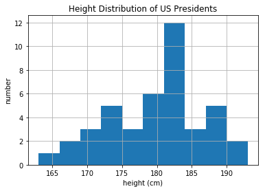

```python
plt.hist(heights)
plt.title('Height Distribution of US Presidents')
plt.xlabel('height (cm)')
plt.ylabel('number')
grid(True)
```

**broadcasting functionality** 就是对两个不同形状的数组进行向量运算

```python
np.array([1,2,3]) + 4
```

```
array([5, 6, 7])
```

```python
np.ones((3, 3)) + np.array([1,2,3])
```

```
array([[ 2.,  3.,  4.],
       [ 2.,  3.,  4.],
       [ 2.,  3.,  4.]])
```

```python
np.arange(3) + np.arange(3)[:, np.newaxis]
```

```
array([[0, 1, 2],
       [1, 2, 3],
       [2, 3, 4]])
```

尺寸扩展规则

- 两个数组维度不一致，则维度少的数组在其左侧维度加一，即扩展维度
- 维度一致了但是尺寸不一致，则维度数组里尺寸为一的那个维度的尺寸扩展为另一个数组对应维度的尺寸
- 如果两个数组任何维度尺寸不为一且尺寸不一致，直接报错

M.shape = (2, 3)

a.shape = (3,)

============

M.shape -> (2, 3)

a.shape -> (1, 3)

============

M.shape -> (2, 3)

a.shape -> (2, 3)

```python
X = np.random.random((10, 3))
Xmean = X.mean(0)
Xmean
```

```
array([ 0.49811223,  0.46392919,  0.43440782])
```

```python
X_centered = X - Xmean
X_centered.mean(0)
```

```
array([  2.77555756e-17,   3.33066907e-17,  -2.22044605e-17])
```

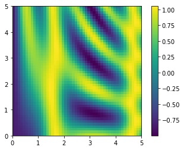

```python
x = np.linspace(0, 5, 50)
y = np.linspace(0, 5, 50)[:, np.newaxis]

z = np.sin(x) ** 10 + np.cos(10 + y * x) * np.cos(x)
plt.imshow(z, origin='lower', extent=[0, 5, 0, 5], cmap='viridis')
plt.colorbar()
```

### 下雨天数统计分析

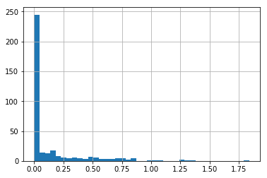

```python
data_path = 'D:/workspace/pycharm/fluent/data-USstates-master/PythonDataScienceHandbook-master/notebooks/data'
rainfall = pd.read_csv(data_path + '/Seattle2014.csv')['PRCP'].values

inches = rainfall / 254
plt.hist(inches, 40)
grid(True)
```

```python
np.sum((inches > 0.5) & (inches < 1))
```

```
29
```

**fancy indexing**奇特的索引

```python
rand = np.random.RandomState(42)
x = rand.randint(100, size=10)
ind = np.array([[3, 7],[4, 5]])
x[ind]
```

```
array([[71, 86],
       [60, 20]])
```

```python
row = np.array([0, 1, 2])
col = np.array([2, 1, 3])

X = np.arange(12).reshape((3, 4))
X[row[:, np.newaxis], col]
```

```
array([[ 2,  1,  3],
       [ 6,  5,  7],
       [10,  9, 11]])
```

```python
mask = np.array([1, 0, 1, 0], dtype=bool)
X[row[:, np.newaxis], mask]
```

```
array([[ 0,  2],
       [ 4,  6],
       [ 8, 10]])
```

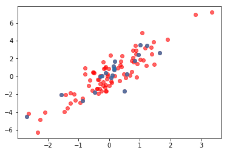

```python
mean = [0, 0]
cov = [[1, 2],
       [2, 5]]

# 多元正态分布 mean 和 协方差矩阵都是嵌套列表
X = rand.multivariate_normal(mean, cov, 100)

plt.plot(X[:, 0], X[:, 1], 'or', alpha= .6)
# 随机抽样 20个点
indices = np.random.choice(X.shape[0], 20, replace=False)

selection = X[indices]
plt.plot(selection[:, 0], selection[:, 1], 'o', alpha=.7)
```

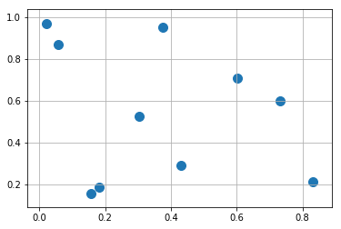

```python
rand = np.random.RandomState(42)
X = rand.rand(10, 2)
plt.scatter(X[:, 0], X[:, 1], s=100)
grid(True)
```

```python
differences = X[:, np.newaxis, :] - X[np.newaxis, :, :]
differences
```

```
array([[[ 0.        ,  0.        ],
        [-0.35745382,  0.35205582],
        [ 0.21852148,  0.79471979],
        [ 0.31645651,  0.08453816],
        [-0.22657489,  0.24264173],
        [ 0.35395562, -0.01919555],
        [-0.45790252,  0.7383752 ],
        [ 0.19271515,  0.7673098 ],
        [ 0.07029788,  0.42595787],
        [-0.0574049 ,  0.65948517]],

       [[ 0.35745382, -0.35205582],
        [ 0.        ,  0.        ],
        [ 0.5759753 ,  0.44266396],
        [ 0.67391033, -0.26751766],
        [ 0.13087893, -0.10941409],
        [ 0.71140945, -0.37125137],
        [-0.1004487 ,  0.38631937],
        [ 0.55016897,  0.41525397],
        [ 0.4277517 ,  0.07390205],
        [ 0.30004892,  0.30742934]],

       [[-0.21852148, -0.79471979],
        [-0.5759753 , -0.44266396],
        [ 0.        ,  0.        ],
        [ 0.09793503, -0.71018163],
        [-0.44509637, -0.55207806],
        [ 0.13543415, -0.81391533],
        [-0.676424  , -0.05634459],
        [-0.02580633, -0.02740999],
        [-0.1482236 , -0.36876191],
        [-0.27592638, -0.13523462]],

       [[-0.31645651, -0.08453816],
        [-0.67391033,  0.26751766],
        [-0.09793503,  0.71018163],
        [ 0.        ,  0.        ],
        [-0.5430314 ,  0.15810357],
        [ 0.03749912, -0.10373371],
        [-0.77435903,  0.65383704],
```

[output cut: 54 more lines]

```
        [-0.5282004 ,  0.31241732],
        [ 0.12241728,  0.34135192],
        [ 0.        ,  0.        ],
        [-0.12770278,  0.23352729]],

       [[ 0.0574049 , -0.65948517],
        [-0.30004892, -0.30742934],
        [ 0.27592638,  0.13523462],
        [ 0.37386141, -0.57494701],
        [-0.16916999, -0.41684344],
        [ 0.41136052, -0.67868071],
        [-0.40049762,  0.07889003],
        [ 0.25012005,  0.10782463],
        [ 0.12770278, -0.23352729],
        [ 0.        ,  0.        ]]])
```

```python
sq_differences = differences ** 2
sq_differences
```

```
array([[[  0.00000000e+00,   0.00000000e+00],
        [  1.27773236e-01,   1.23943302e-01],
        [  4.77516365e-02,   6.31579538e-01],
        [  1.00144721e-01,   7.14670060e-03],
        [  5.13361821e-02,   5.88750085e-02],
        [  1.25284584e-01,   3.68468977e-04],
        [  2.09674720e-01,   5.45197930e-01],
        [  3.71391297e-02,   5.88764324e-01],
        [  4.94179135e-03,   1.81440111e-01],
        [  3.29532252e-03,   4.34920684e-01]],

       [[  1.27773236e-01,   1.23943302e-01],
        [  0.00000000e+00,   0.00000000e+00],
        [  3.31747548e-01,   1.95951385e-01],
        [  4.54155132e-01,   7.15656993e-02],
        [  1.71292943e-02,   1.19714439e-02],
        [  5.06103402e-01,   1.37827578e-01],
        [  1.00899411e-02,   1.49242658e-01],
        [  3.02685901e-01,   1.72435863e-01],
        [  1.82971516e-01,   5.46151337e-03],
        [  9.00293563e-02,   9.45128016e-02]],

       [[  4.77516365e-02,   6.31579538e-01],
        [  3.31747548e-01,   1.95951385e-01],
        [  0.00000000e+00,   0.00000000e+00],
        [  9.59126976e-03,   5.04357941e-01],
        [  1.98110780e-01,   3.04790182e-01],
        [  1.83424079e-02,   6.62458167e-01],
        [  4.57549428e-01,   3.17471286e-03],
        [  6.65966501e-04,   7.51307525e-04],
        [  2.19702363e-02,   1.35985347e-01],
        [  7.61353662e-02,   1.82884024e-02]],

       [[  1.00144721e-01,   7.14670060e-03],
        [  4.54155132e-01,   7.15656993e-02],
        [  9.59126976e-03,   5.04357941e-01],
        [  0.00000000e+00,   0.00000000e+00],
        [  2.94883101e-01,   2.49967382e-02],
        [  1.40618384e-03,   1.07606818e-02],
        [  5.99631905e-01,   4.27502868e-01],
```

[output cut: 54 more lines]

```
        [  2.78995660e-01,   9.76045824e-02],
        [  1.49859894e-02,   1.16521135e-01],
        [  0.00000000e+00,   0.00000000e+00],
        [  1.63079989e-02,   5.45349958e-02]],

       [[  3.29532252e-03,   4.34920684e-01],
        [  9.00293563e-02,   9.45128016e-02],
        [  7.61353662e-02,   1.82884024e-02],
        [  1.39772351e-01,   3.30564059e-01],
        [  2.86184866e-02,   1.73758451e-01],
        [  1.69217481e-01,   4.60607509e-01],
        [  1.60398345e-01,   6.22363676e-03],
        [  6.25600401e-02,   1.16261509e-02],
        [  1.63079989e-02,   5.45349958e-02],
        [  0.00000000e+00,   0.00000000e+00]]])
```

```python
dist_sq = sq_differences.sum(-1)
dist_sq
```

```
array([[ 0.        ,  0.25171654,  0.67933117,  0.10729142,  0.11021119,
         0.12565305,  0.75487265,  0.62590345,  0.1863819 ,  0.43821601],
       [ 0.25171654,  0.        ,  0.52769893,  0.52572083,  0.02910074,
         0.64393098,  0.1593326 ,  0.47512176,  0.18843303,  0.18454216],
       [ 0.67933117,  0.52769893,  0.        ,  0.51394921,  0.50290096,
         0.68080058,  0.46072414,  0.00141727,  0.15795558,  0.09442377],
       [ 0.10729142,  0.52572083,  0.51394921,  0.        ,  0.31987984,
         0.01216687,  1.02713477,  0.48148903,  0.17716149,  0.47033641],
       [ 0.11021119,  0.02910074,  0.50290096,  0.31987984,  0.        ,
         0.40557444,  0.29926414,  0.45108072,  0.12173825,  0.20237694],
       [ 0.12565305,  0.64393098,  0.68080058,  0.01216687,  0.40557444,
         0.        ,  1.23302708,  0.64458914,  0.27862329,  0.62982499],
       [ 0.75487265,  0.1593326 ,  0.46072414,  1.02713477,  0.29926414,
         1.23302708,  0.        ,  0.42414057,  0.37660024,  0.16662198],
       [ 0.62590345,  0.47512176,  0.00141727,  0.48148903,  0.45108072,
         0.64458914,  0.42414057,  0.        ,  0.13150712,  0.07418619],
       [ 0.1863819 ,  0.18843303,  0.15795558,  0.17716149,  0.12173825,
         0.27862329,  0.37660024,  0.13150712,  0.        ,  0.07084299],
       [ 0.43821601,  0.18454216,  0.09442377,  0.47033641,  0.20237694,
         0.62982499,  0.16662198,  0.07418619,  0.07084299,  0.        ]])
```

argsort(x, axis=1) 按照行排序，返回的值是索引位置

```python
nearest = np.argsort(dist_sq, axis=1)
print(nearest)
```

```
[[0 3 4 5 8 1 9 7 2 6]
 [1 4 6 9 8 0 7 3 2 5]
 [2 7 9 8 6 4 3 1 0 5]
 [3 5 0 8 4 9 7 2 1 6]
 [4 1 0 8 9 6 3 5 7 2]
 [5 3 0 8 4 9 1 7 2 6]
 [6 1 9 4 8 7 2 0 3 5]
 [7 2 9 8 6 4 1 3 0 5]
 [8 9 4 7 2 3 0 1 5 6]
 [9 8 7 2 6 1 4 0 3 5]]
```

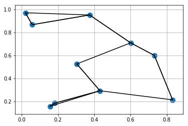

```python
K = 2
nearest_partition = np.argpartition(dist_sq, K + 1, axis=1)
plt.scatter(X[:, 0], X[:, 1], s=100)
# draw lines from each point to its two nearest neighbors
K = 2
for i in range(X.shape[0]):
    for j in nearest_partition[i, :K+1]:
        # plot a line from X[i] to X[j]
        # use some zip magic to make it happen:
        plt.plot(*zip(X[j], X[i]), color='black')
grid(True)
```

### pandas 跟 MySQL 交互

- python3 安装 pip install mysqlclient

```python
import MySQLdb

# 读取sakila数据库中actor表的前10条数据，保存为pandas的数据框
conn =  MySQLdb.connect(host="localhost", user="root",passwd="7612",db='sakila',charset='utf8')
sql = "select * from actor limit 10"
df = pd.read_sql(sql, conn)
df
```

|  | actor_id | first_name | last_name | last_update |
| --- | --- | --- | --- | --- |
| 0 | 1 | PENELOPE | GUINESS | 2006-02-15 04:34:33 |
| 1 | 2 | NICK | WAHLBERG | 2006-02-15 04:34:33 |
| 2 | 3 | ED | CHASE | 2006-02-15 04:34:33 |
| 3 | 4 | JENNIFER | DAVIS | 2006-02-15 04:34:33 |
| 4 | 5 | JOHNNY | LOLLOBRIGIDA | 2006-02-15 04:34:33 |
| 5 | 6 | BETTE | NICHOLSON | 2006-02-15 04:34:33 |
| 6 | 7 | GRACE | MOSTEL | 2006-02-15 04:34:33 |
| 7 | 8 | MATTHEW | JOHANSSON | 2006-02-15 04:34:33 |
| 8 | 9 | JOE | SWANK | 2006-02-15 04:34:33 |
| 9 | 10 | CHRISTIAN | GABLE | 2006-02-15 04:34:33 |

```python
from sqlalchemy import create_engine
conn_write = create_engine('mysql://root:7612@localhost:3306/python_db?charset=utf8')

# ipython环境下有bug，用原生的shell没问题
# df.to_sql('actor', conn_write)
df.to_json()
```

```
'{"actor_id":{"0":1,"1":2,"2":3,"3":4,"4":5,"5":6,"6":7,"7":8,"8":9,"9":10},"first_name":{"0":"PENELOPE","1":"NICK","2":"ED","3":"JENNIFER","4":"JOHNNY","5":"BETTE","6":"GRACE","7":"MATTHEW","8":"JOE","9":"CHRISTIAN"},"last_name":{"0":"GUINESS","1":"WAHLBERG","2":"CHASE","3":"DAVIS","4":"LOLLOBRIGID…
```

```python
area_dict = {'California': 423967, 'Texas': 695662, 'New York': 141297,'Florida': 170312, 'Illinois': 149995}
population_dict = {'California': 38332521,
                   'Texas': 26448193,
                   'New York': 19651127,
                   'Florida': 19552860,
                   'Illinois': 12882135}
data = pd.DataFrame({'pop':population_dict, 'area':area_dict})
data
```

|  | area | pop |
| --- | --- | --- |
| California | 423967 | 38332521 |
| Florida | 170312 | 19552860 |
| Illinois | 149995 | 12882135 |
| New York | 141297 | 19651127 |
| Texas | 695662 | 26448193 |

```python
data.index
```

```
Index(['California', 'Florida', 'Illinois', 'New York', 'Texas'], dtype='object')
```

```python
data.columns
```

```
Index(['area', 'pop'], dtype='object')
```

### pandas 里的索引

```python
data = pd.Series([0.25, 0.5, 0.75, 1.0],
index=['a', 'b', 'c', 'd'])
data
```

```
a    0.25
b    0.50
c    0.75
d    1.00
dtype: float64
```

```python
# 创建索引
ind = pd.Index([1,2,3,4])
print(ind)
# 索引对象是不可变的数组
ind[1] = 0
# 支持与集合相关的操作，& | ^
```

```
Int64Index([1, 2, 3, 4], dtype='int64')
```

```
---------------------------------------------------------------------------
TypeError                                 Traceback (most recent call last)
<ipython-input-12-df1b181d8aeb> in <module>()
      3 print(ind)
      4 # 索引对象是不可变的数组
----> 5 ind[1] = 0
      6 # 支持与集合相关的操作，& | ^

c:\users\dw\appdata\local\programs\python\python36\lib\site-packages\pandas\core\indexes\base.py in __setitem__(self, key, value)
   1668
   1669     def __setitem__(self, key, value):
-> 1670         raise TypeError("Index does not support mutable operations")
   1671
   1672     def __getitem__(self, key):

TypeError: Index does not support mutable operations
```

像字典一样提取索引和值

```python
data['b']
```

```
0.5
```

```python
data.keys()
```

```
Index(['a', 'b', 'c', 'd'], dtype='object')
```

```python
list(data.items())
```

```
[('a', 0.25), ('b', 0.5), ('c', 0.75), ('d', 1.0)]
```

```python
data['e'] = 1.25
data
```

```
a    0.25
b    0.50
c    0.75
d    1.00
e    1.25
dtype: float64
```

索引和切片

```python
# 指定索引名（显式）用来切片
# 包含了切片的最后一个索引'c'
data['a':'c']
```

```
a    0.25
b    0.50
c    0.75
dtype: float64
```

```python
# 未明确指定索引（隐式）来切片
# 即只考虑实际的索引位置
# 不包含最后的索引2，如同python自带的list索引一样
data[0:2]
```

```
a    0.25
b    0.50
dtype: float64
```

```python
data = pd.Series(['a', 'b', 'c'], index=[1, 3, 5])
data
```

```
1    a
3    b
5    c
dtype: object
```

```python
# 如果整数就是索引
# 默认就是显式索引
data[1]
```

```
'a'
```

```python
# 当切片时，整数代表隐式索引
data[1:3]
```

```
3    b
5    c
dtype: object
```

```python
# loc 索引器永远是显式索引
data.loc[1]
```

```
'a'
```

```python
data.loc[1:3]
```

```
1    a
3    b
dtype: object
```

```python
# iloc 索引器永远是隐式索引
data.iloc[1]
data.iloc[1:3]
# ix 支持混合式索引,不过在最新版本里已经弃用
```

```
3    b
5    c
dtype: object
```

数据框的索引

```python
 area = pd.Series({'California': 423967, 'Texas': 695662,
'New York': 141297, 'Florida': 170312,
'Illinois': 149995})
pop = pd.Series({'California': 38332521, 'Texas': 26448193,
'New York': 19651127, 'Florida': 19552860,
'Illinois': 12882135})
data = pd.DataFrame({'area':area, 'pop':pop})
data
```

|  | area | pop |
| --- | --- | --- |
| California | 423967 | 38332521 |
| Florida | 170312 | 19552860 |
| Illinois | 149995 | 12882135 |
| New York | 141297 | 19651127 |
| Texas | 695662 | 26448193 |

```python
data.loc[['California', 'Illinois'], :'pop']
```

|  | area | pop |
| --- | --- | --- |
| California | 423967 | 38332521 |
| Illinois | 149995 | 12882135 |

```python
data['density'] = data['pop'] / data['area']
data
```

|  | area | pop | density |
| --- | --- | --- | --- |
| California | 423967 | 38332521 | 90.413926 |
| Florida | 170312 | 19552860 | 114.806121 |
| Illinois | 149995 | 12882135 | 85.883763 |
| New York | 141297 | 19651127 | 139.076746 |
| Texas | 695662 | 26448193 | 38.018740 |

```python
data.iloc[0, 2] = 90
data
```

|  | area | pop | density |
| --- | --- | --- | --- |
| California | 423967 | 38332521 | 90.000000 |
| Florida | 170312 | 19552860 | 114.806121 |
| Illinois | 149995 | 12882135 | 85.883763 |
| New York | 141297 | 19651127 | 139.076746 |
| Texas | 695662 | 26448193 | 38.018740 |

```python
data['Florida':'Illinois']
```

|  | area | pop | density |
| --- | --- | --- | --- |
| Florida | 170312 | 19552860 | 114.806121 |
| Illinois | 149995 | 12882135 | 85.883763 |

```python
data[:'density']
```

[output not shown]

```python
# 索引自动对齐，缺失索引自动为NaN
area = pd.Series({'Alaska': 1723337, 'Texas': 695662,
                  'California': 423967}, name='area')
population = pd.Series({'California': 38332521, 'Texas': 26448193,
                        'New York': 19651127}, name='population')
population / area
```

```
Alaska              NaN
California    90.413926
New York            NaN
Texas         38.018740
dtype: float64
```

```python
area.index | population.index
```

```
Index(['Alaska', 'California', 'New York', 'Texas'], dtype='object')
```

```python
A = pd.Series([2, 4, 6], index=[0, 1, 2])
B = pd.Series([1, 3, 5], index=[1, 2, 3])
A + B
```

```
0    NaN
1    5.0
2    9.0
3    NaN
dtype: float64
```

```python
A.add(B, fill_value=0)
```

```
0    2.0
1    5.0
2    9.0
3    5.0
dtype: float64
```

```python
rng = np.random.RandomState(42)
A = pd.DataFrame(rng.randint(0, 20, (2, 2)),
                 columns=list('AB'))

B = pd.DataFrame(rng.randint(0, 10, (3, 3)),
                 columns=list('BAC'))

A + B
```

|  | A | B | C |
| --- | --- | --- | --- |
| 0 | 10.0 | 26.0 | NaN |
| 1 | 16.0 | 19.0 | NaN |
| 2 | NaN | NaN | NaN |

```python
A.stack()
```

```
0  A     6
   B    19
1  A    14
   B    10
dtype: int32
```

```python
fill = A.stack().mean()
fill
```

```
12.25
```

```python
A.add(B, fill_value=fill)
```

|  | A | B | C |
| --- | --- | --- | --- |
| 0 | 10.00 | 26.00 | 18.25 |
| 1 | 16.00 | 19.00 | 18.25 |
| 2 | 16.25 | 19.25 | 15.25 |

```python
A = rng.randint(10, size=(3, 4))
df = pd.DataFrame(A, columns=list('QRST'))
print(df)
print(df - df.iloc[0])
```

```
   Q  R  S  T
0  3  6  7  2
1  0  3  1  7
2  3  1  5  5
   Q  R  S  T
0  0  0  0  0
1 -3 -3 -6  5
2  0 -5 -2  3
```

```python
halfrow = df.iloc[0, ::2]
halfrow
```

```
Q    3
S    7
Name: 0, dtype: int32
```

```python
df - halfrow
```

|  | Q | R | S | T |
| --- | --- | --- | --- | --- |
| 0 | 0.0 | NaN | 0.0 | NaN |
| 1 | -3.0 | NaN | -6.0 | NaN |
| 2 | 0.0 | NaN | -2.0 | NaN |

### pandas 多层索引

```python
index = [('California', 2000), ('California', 2010),
         ('New York', 2000), ('New York', 2010),
         ('Texas', 2000), ('Texas', 2010)]
index = pd.MultiIndex.from_tuples(index)
index
```

```
MultiIndex(levels=[['California', 'New York', 'Texas'], [2000, 2010]],
           labels=[[0, 0, 1, 1, 2, 2], [0, 1, 0, 1, 0, 1]])
```

```python
populations = [33871648, 37253956,
18976457, 19378102,
20851820, 25145561]
pop = pd.Series(populations, index=index)
pop
```

```
California  2000    33871648
            2010    37253956
New York    2000    18976457
            2010    19378102
Texas       2000    20851820
            2010    25145561
dtype: int64
```

```python
pop[:, 2010]
```

```
California    37253956
New York      19378102
Texas         25145561
dtype: int64
```

```python
pop_df = pop.unstack()
pop_df
```

|  | 2000 | 2010 |
| --- | --- | --- |
| California | 33871648 | 37253956 |
| New York | 18976457 | 19378102 |
| Texas | 20851820 | 25145561 |

```python
pop_df.stack()
```

```
California  2000    33871648
            2010    37253956
New York    2000    18976457
            2010    19378102
Texas       2000    20851820
            2010    25145561
dtype: int64
```

```python
index = pd.MultiIndex.from_product([[2013, 2014], [1, 2]],
names=['year', 'visit'])
columns = pd.MultiIndex.from_product([['Bob', 'Guido', 'Sue'], ['HR', 'Temp']],
names=['subject', 'type'])
# mock some data
data = np.round(np.random.randn(4, 6), 1)
data[:, ::2] *= 10
data += 37
# create the DataFrame
health_data = pd.DataFrame(data, index=index, columns=columns)
health_data
```

| year | subject type visit | Bob HR | Bob Temp | Guido HR | Guido Temp | Sue HR | Sue Temp |
| --- | --- | --- | --- | --- | --- | --- | --- |
| 2013 | 1 | 35.0 | 37.7 | 43.0 | 36.2 | 51.0 | 35.9 |
|  | 2 | 35.0 | 36.6 | 48.0 | 36.2 | 35.0 | 38.2 |
| 2014 | 1 | 31.0 | 37.2 | 47.0 | 37.9 | 40.0 | 38.0 |
|  | 2 | 31.0 | 37.6 | 37.0 | 36.9 | 38.0 | 36.2 |

```python
health_data['Guido']
```

| year | type visit | HR | Temp |
| --- | --- | --- | --- |
| 2013 | 1 | 43.0 | 36.2 |
|  | 2 | 48.0 | 36.2 |
| 2014 | 1 | 47.0 | 37.9 |
|  | 2 | 37.0 | 36.9 |

```python
health_data['Guido', 'HR']
```

```
year  visit
2013  1        43.0
      2        48.0
2014  1        47.0
      2        37.0
Name: (Guido, HR), dtype: float64
```

```python
health_data.iloc[:2, :2]
```

| year | subject type visit | Bob HR | Bob Temp |
| --- | --- | --- | --- |
| 2013 | 1 | 35.0 | 37.7 |
|  | 2 | 35.0 | 36.6 |

```python
health_data.loc[:, ('Bob', 'HR')]
```

```
year  visit
2013  1        35.0
      2        35.0
2014  1        31.0
      2        31.0
Name: (Bob, HR), dtype: float64
```

```python
idx = pd.IndexSlice
health_data.loc[idx[:, 1], idx[:, 'HR']]
```

| year | subject type visit | Bob HR | Guido HR | Sue HR |
| --- | --- | --- | --- | --- |
| 2013 | 1 | 35.0 | 43.0 | 51.0 |
| 2014 | 1 | 31.0 | 47.0 | 40.0 |